# Exercise 4: EZ-Diffusion Model

In this exercise, we will have a look at estimating the parameters from the diffusion decision model using the hierarchical Bayesian implementation of the ez-Diffusion Model. This implementation allows for a fast parameter estimation while still providing acceptable recovery of three parameters of interest:

1. drift rate = the rate of evidence accumulation
2. boundary seperation = the seperation of decision thresholds
3. non-decision time = the time for non-decisional processes.

Your task is to load one of the data sets we prepared for this exercise, either `exc4_VisualSearch.txt` or `exc5_ColorJudgement.txt`.

The Color Judgement data set contains data of 50 participants that completed a Color Judgement task. In this task participants saw an array of blue and red dots and should decide if the array contained more blue or red dots. There were two difficulty levels, the easy level in which 60% of the dots were either blue or red, and the difficult level in which 52% of the dots were either blue or red.

Your task is:

1. aggregate the data, so that we can estimate the `ezdm`
2. to specify the `ezdm` model object matching the aggreaged data of the task
3. specify a model formula predicting which parameters you assume to vary as a function of the difficulty level
4. estimate the model using the `bmm` function and interpret the results with respect to the experimental effects on the model parameters

## Solution

```r
# Load required packages
library(bmm)
library(tidyverse)
library(here)
```

### Prepare Data

First, we need to aggregate the data so that we can analyze our data with the `ezdm` using the `bmm` function. For this, we need to calcualte the mean reaction time, the varianve of the reaction time, the number of correct responses, and the number of trials in each cell of the experimental design.

```r
ezdm_data <- read.table(here("data","exc5_ColorJudgementTask.txt"),
                        header = T, sep = ",")

ezdm_data_agg <- ezdm_data %>%
  filter(rt > 150, rt < 5000) %>%
  summarise(
    mean_rt = mean(rt/1000),
    var_rt = var(rt/1000),
    n_correct = sum(correct),
    n_trials = n(),
    .by = c("participant_id", "condition", "correct_response")
  )

ezdm_data_agg$condition <- as.factor(ezdm_data_agg$condition)
contrasts(ezdm_data_agg$condition) <- bayestestR::contr.equalprior
```

### Specify Model object

Next, we need to specify the model object to link which data columns are used to identify the `ezdm`

```r
ezdm_model <- ezdm(mean_rt = "mean_rt", var_rt = "var_rt", n_correct = "n_correct",
                   n_trials = "n_trials")
```

### Specify the BMM formula

Now, we can consider which parameters are affected by the experimental manipulations. First, let’s see how the `ezdm` parameter vary as a function of the difficutly manipulation.

```r
ezdm_formula <- bmf(
  drift ~ 1 + condition + (1 + condition | participant_id),
  bound ~  1 + (1 | participant_id),
  ndt ~  1 + condition + (1 + condition | participant_id)
)
```

### Estimate `ezdm` with the `bmm` function

Finally, we can estimate the model using our aggregated data, the `bmmodel` object we created and the `bmmformula` specifying how the model parameters should change over experimental condition.

```r
ezdm_fit <- bmm(
  formula = ezdm_formula,
  data = ezdm_data_agg,
  model = ezdm_model,
  cores = 4,
  sample_prior = TRUE
)
```

```
## Running MCMC with 4 parallel chains...
```

[output not shown]

[output cut: 41 more lines]

[output not shown]

```r
summary(ezdm_fit)
```

```
##   Model: ezdm(mean_rt = "mean_rt",
##               var_rt = "var_rt",
##               n_correct = "n_correct",
##               n_trials = "n_trials")
##   Links: drift = identity; bound = log; ndt = log
## Formula: drift ~ 1 + condition + (1 + condition | participant_id)
##          bound ~ 1 + (1 | participant_id)
##          ndt ~ 1 + condition + (1 + condition | participant_id)
##    Data: ezdm_data_agg (Number of observations: 200)
##   Draws: 4 chains, each with iter = 2000; warmup = 1000; thin = 1;
##          total post-warmup draws = 4000
##
## Multilevel Hyperparameters:
## ~participant_id (Number of levels: 50)
##                                       Estimate Est.Error l-95% CI u-95% CI Rhat
## sd(drift_Intercept)                       0.49      0.05     0.40     0.63 1.01
## sd(drift_condition1)                      0.43      0.05     0.35     0.55 1.01
## sd(bound_Intercept)                       0.27      0.03     0.22     0.33 1.00
## sd(ndt_Intercept)                         0.33      0.05     0.24     0.45 1.00
## sd(ndt_condition1)                        0.19      0.04     0.11     0.27 1.00
## cor(drift_Intercept,drift_condition1)    -0.94      0.03    -0.98    -0.87 1.00
## cor(ndt_Intercept,ndt_condition1)        -0.33      0.24    -0.75     0.19 1.00
##                                       Bulk_ESS Tail_ESS
## sd(drift_Intercept)                        860     1444
## sd(drift_condition1)                      1021     1524
## sd(bound_Intercept)                        616     1503
## sd(ndt_Intercept)                         1465     2300
## sd(ndt_condition1)                        1406     1613
## cor(drift_Intercept,drift_condition1)     1395     1812
## cor(ndt_Intercept,ndt_condition1)         1531     2135
##
## Regression Coefficients:
##                  Estimate Est.Error l-95% CI u-95% CI Rhat Bulk_ESS Tail_ESS
## drift_Intercept      1.14      0.07     1.00     1.29 1.01      287      812
## bound_Intercept      0.63      0.04     0.56     0.70 1.01      353      692
## ndt_Intercept       -0.94      0.05    -1.05    -0.84 1.00      784     1490
## drift_condition1    -0.80      0.06    -0.92    -0.67 1.01      337      757
## ndt_condition1       0.28      0.04     0.21     0.36 1.00     2128     2743
##
## Draws were sampled using sample(hmc). For each parameter, Bulk_ESS
## and Tail_ESS are effective sample size measures, and Rhat is the potential
## scale reduction factor on split chains (at convergence, Rhat = 1).
```

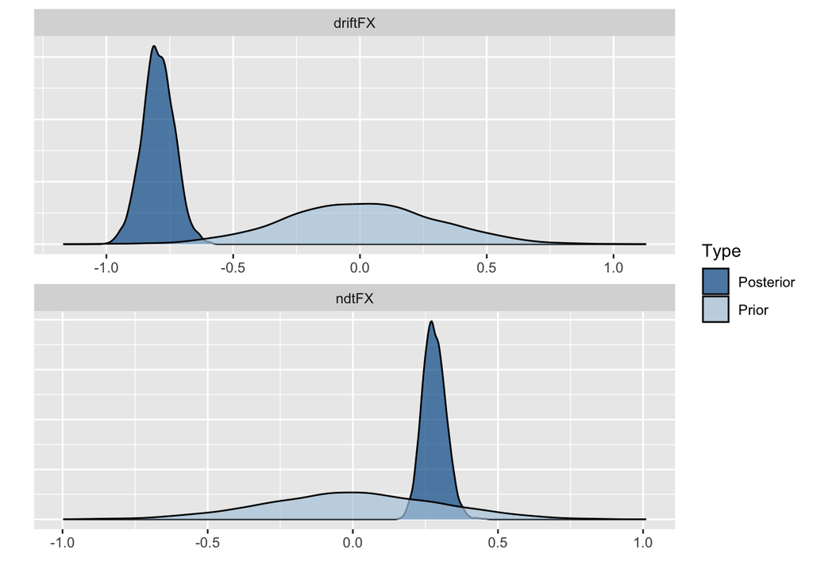

```r
ezdm_hypothesis <- c(
  driftFX = "drift_condition1 = 0",
  ndtFX = "ndt_condition1 = 0"
)

ezdm_hypothesis_results <- brms::hypothesis(
  ezdm_fit,
  ezdm_hypothesis
)

plot(ezdm_hypothesis_results)
```

```r
1/abs(ezdm_hypothesis_results$hypothesis$Evid.Ratio)
```

```
## [1] 1.208969e+18 2.600200e+15
```